```yaml
---
title: "Markdown"
output:
  pdf_document:
    latex_engine: xelatex
  keep_tex: true
  header-includes:
   - \XeTeXdefaultencoding cp1251
   - \usepackage{xltxtra}
   - \usepackage{fontspec}
   - \setmainfont{Times New Roman}
   - \setsansfont{Arial}
   - \setmonofont{Courier New}
   - \newfontfamily{\cyrillicfont}{Times New Roman}
   - \newfontfamily{\cyrillicfonttt}{Courier New}
   - \newfontfamily{\cyrillicfontsf}{Arial}
   - \usepackage[english,russian]{babel}
  html_document: default
date: "2023-10-24"
---
```

# Виды анализа и R Markdown

Это лабораторная работа **Виды анализа и R Markdown**. Ссылка на github-проект, содержащий копию этого файла, а также полученные RMD, PDF и HTML файлы: https://github.com/Roundabout1/R-test.

## Разведочный анализ

Работа [К СТАТИСТИЧЕСКОЙ МЕТОДИКЕ ИЗУЧЕНИЯ КУЛЬТУРНЫХ СЛОЕВ ПОСЕЛЕНИЙ ЭПОХИ БРОНЗЫ (РАБОТА НАД ОШИБКАМИ)](https://cyberleninka.ru/article/n/k-statisticheskoy-metodike-izucheniya-kulturnyh-sloev-poseleniy-epohi-bronzy-rabota-nad-oshibkami) является разведочным анализом данных, так как в ней присутствует:

- методы статистического анализа
- подсчёт статистических числовых параметров, таких как среднеквадратическое отклонение: $\sigma=\sqrt{\frac{\Sigma(x-X)^2}{n-1}}$
- формирование случайной выборки
- анализ статистических результатов

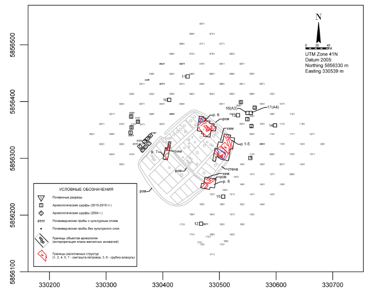

Поселение Каменный Амбар: структура памятника по данным магнитометрии, места расположения раскопок и зона археологической разведки в прилегающей округе

## Причинно-следственный анализ

В статье [Causal Analysis of Health Interventions and Environments for Influencing the Spread of COVID-19 in the United States of America](https://www.frontiersin.org/articles/10.3389/fams.2020.611805/full) исследуются причинно-следственные связи вмешательства со стороны государства на распространение коронавируса в США, исследователи пришли к следующим выводам:

1. Плотность населения — это наиболее значительный фактор

> We found that population density was the most significant causal factor of both new cases and death from COVID-19.
2. Больше чёрнокожих американцев погибало от COVID-19.

> We also discovered that more Black Americans were dying from COVID-19.
3. Отсутствие сильного вмешательства со стороны государства ялвялось причиной многих смертей от COVID-19.

> Our results showed that the high numbers of cases and deaths from COVID-19 were due to lacking strong interventions

| Cause | Effect | Smallest $p$-value | Cause | Effect | Smallest $p%-value |
| --- | --- | --- | --- | --- | --- |
| Retail | COVID-19 case | $7.67E-26$ | COVID-19 case | Retail | $1.29E-04$ |
| Grocery |  | $3.70E-25$ |  | Grocery | $4.85E-11$ |
| Parks |  | $3.87E-23$ |  | Parks | $1.80E-12$ |
| Transit |  | $1.90E-27$ |  | Transit | $1.29E-04$ |
| Workplaces |  | $1.07E-25$ |  | Workplaces | $3.99E-06$ |
| Residential |  | $1.09E-25$ |  | Residential | $2.99E-07$ |